# 06_1_make_simulation_data

Suguru Otani

2024-01-26

# load

## ARIMA (1,0,0) va dependency 0

### cobb_douglas

#### num_time_50_cobb_douglas_0.3_AR1_I0_va_dependency_0

##### unemployed

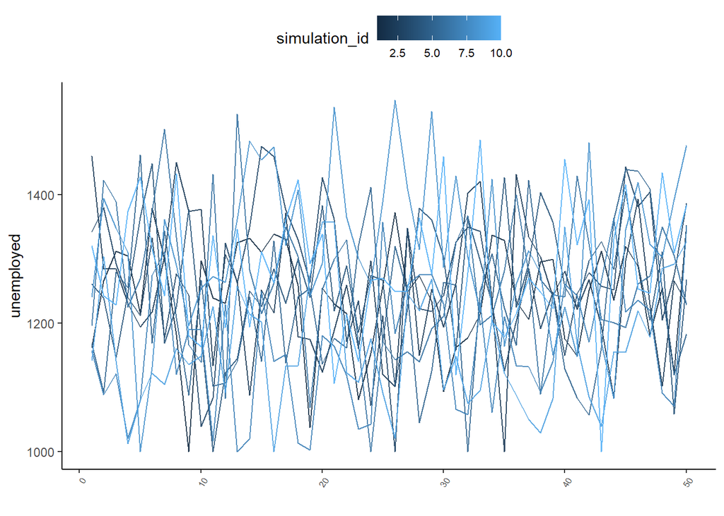

##### position_count

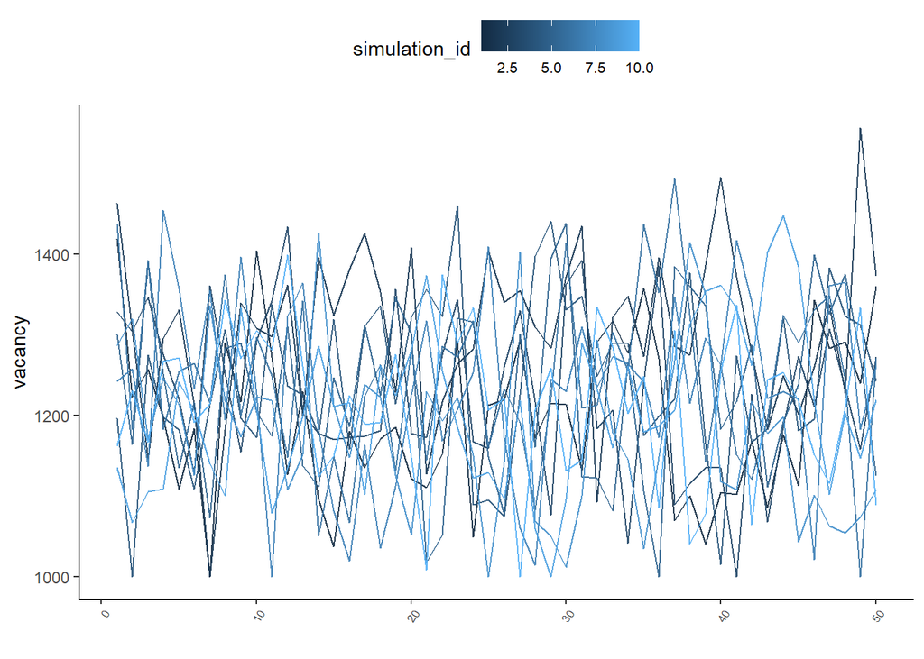

##### hire_count

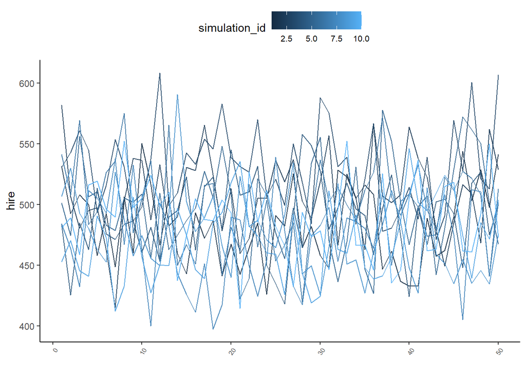

##### normalized_efficiency

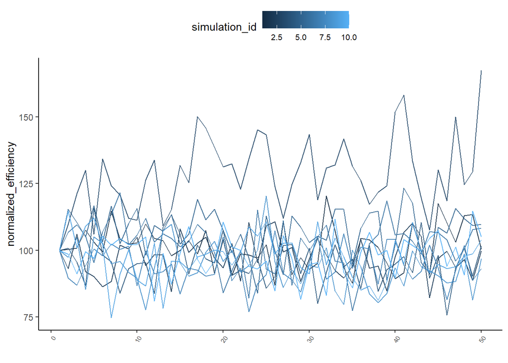

#### num_time_100_cobb_douglas_0.3_AR1_I0_va_dependency_0

##### unemployed

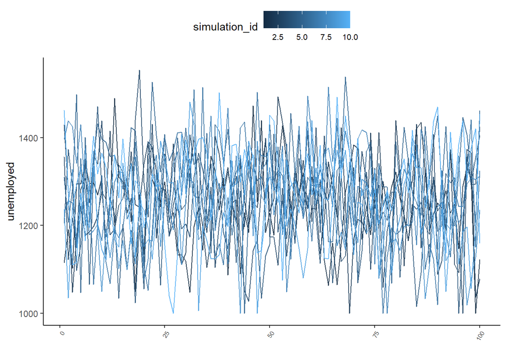

##### position_count

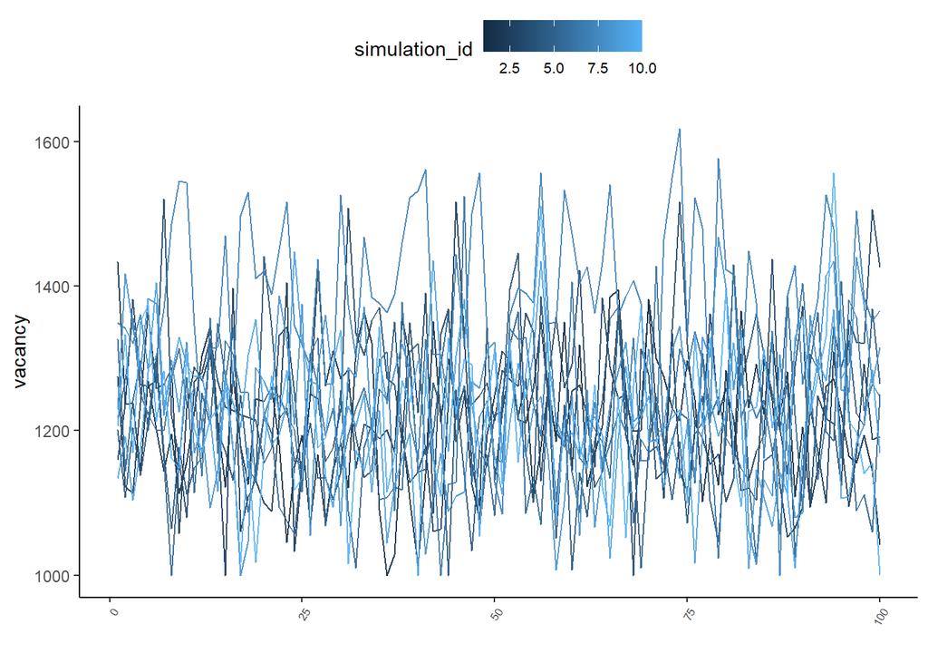

##### hire_count

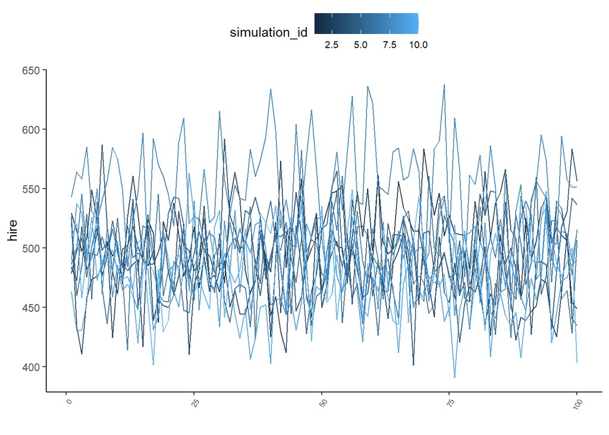

##### normalized_efficiency

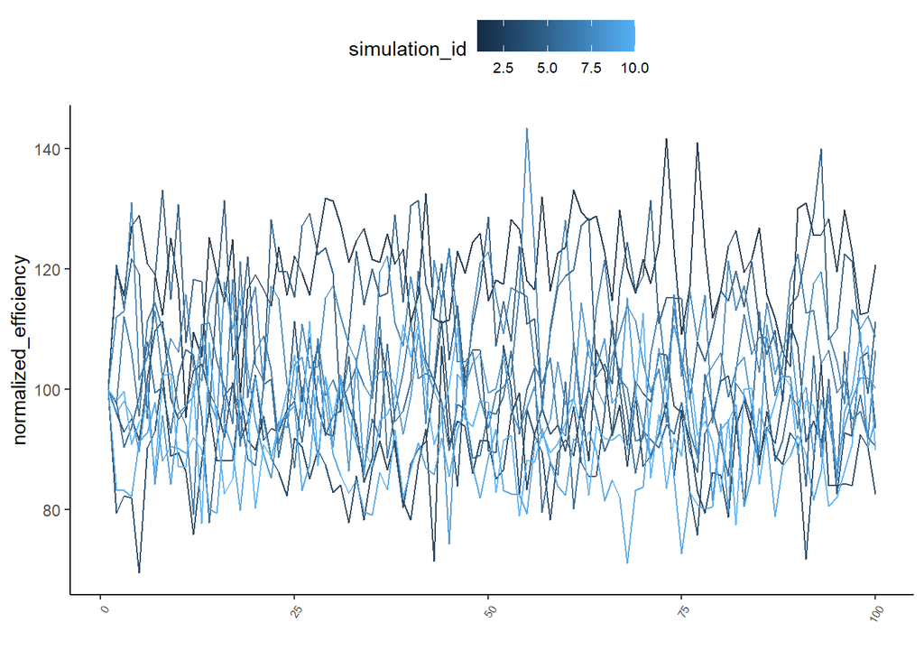

### perfect_substitute

#### num_time_50_perfect_substitute_0.3_AR1_I0_va_dependency_0

##### unemployed

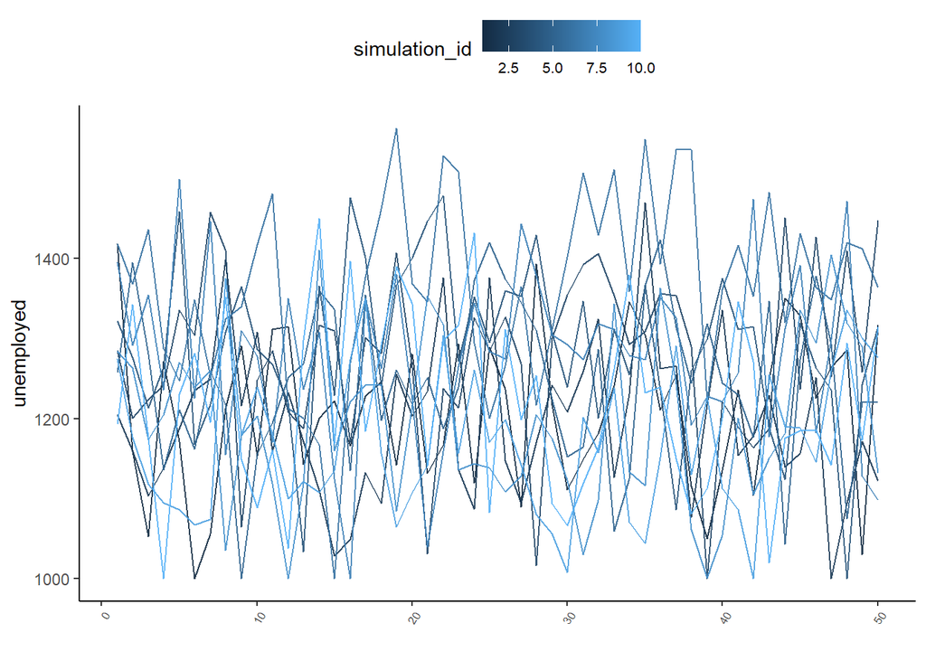

##### position_count

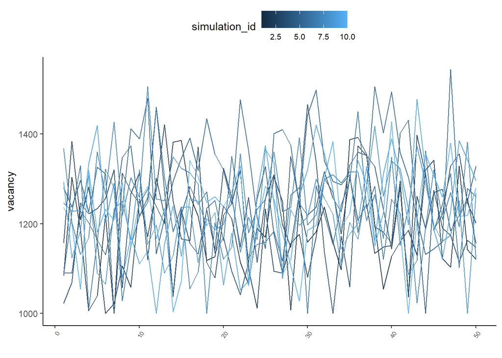

##### hire_count

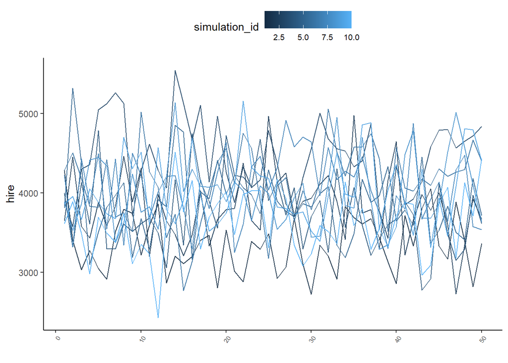

##### normalized_efficiency

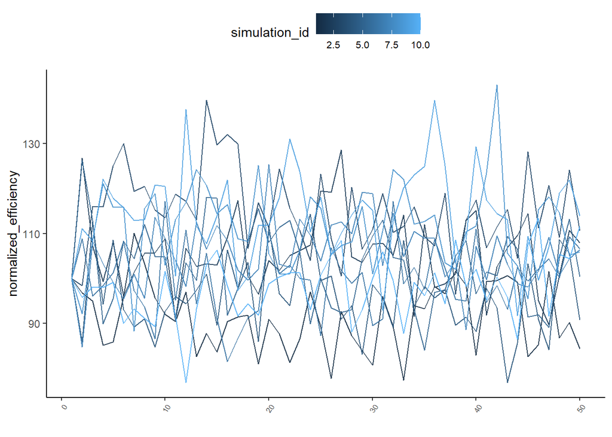

#### num_time_100_perfect_substitute_0.3_AR1_I0_va_dependency_0

##### unemployed

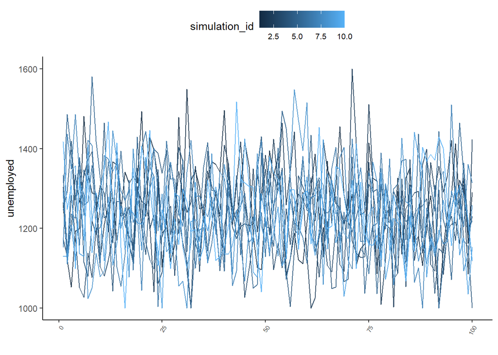

##### position_count

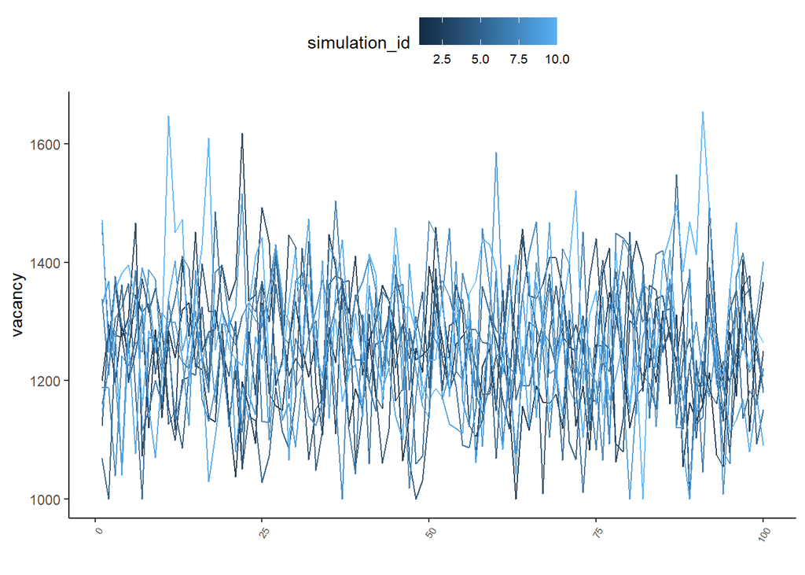

##### hire_count

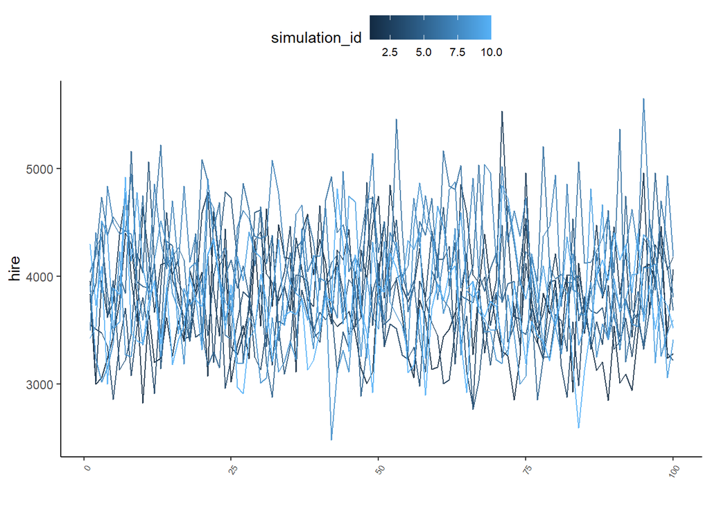

##### normalized_efficiency

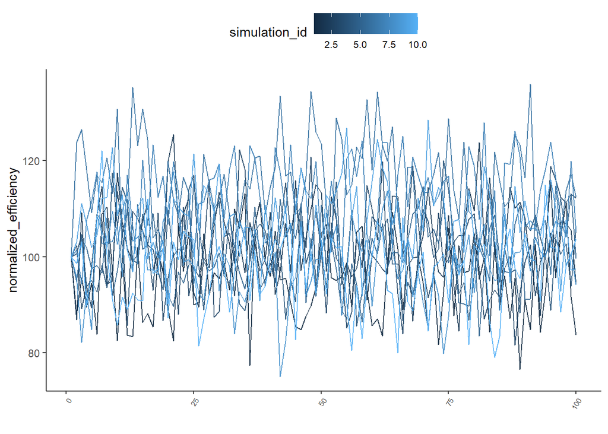

## ARIMA (0,1,0) i.e. nonstationary

### cobb_douglas

#### num_time_50_cobb_douglas_0.3_AR0_I1_va_dependency_0

##### unemployed

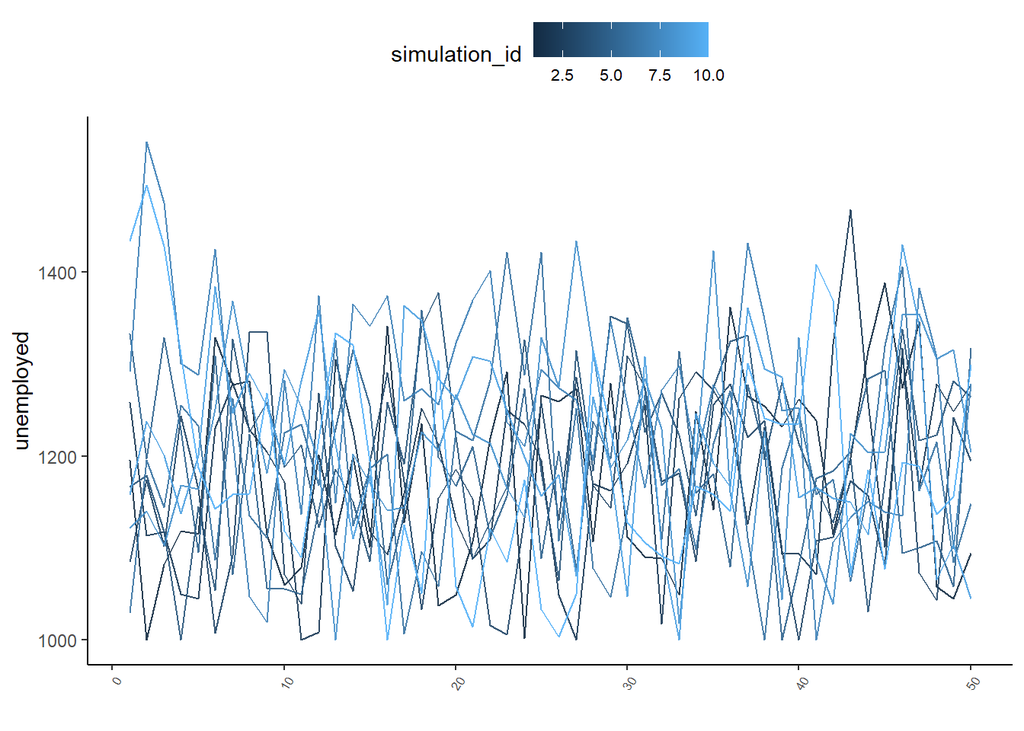

##### position_count

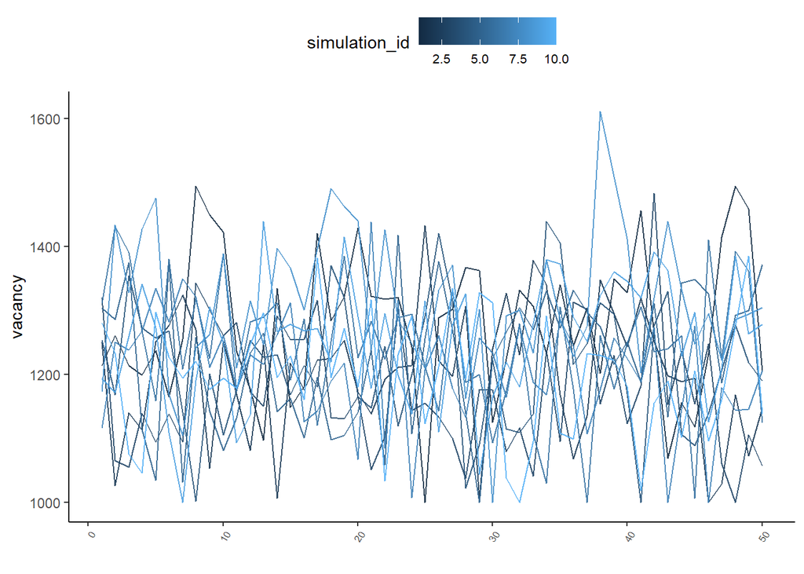

##### hire_count

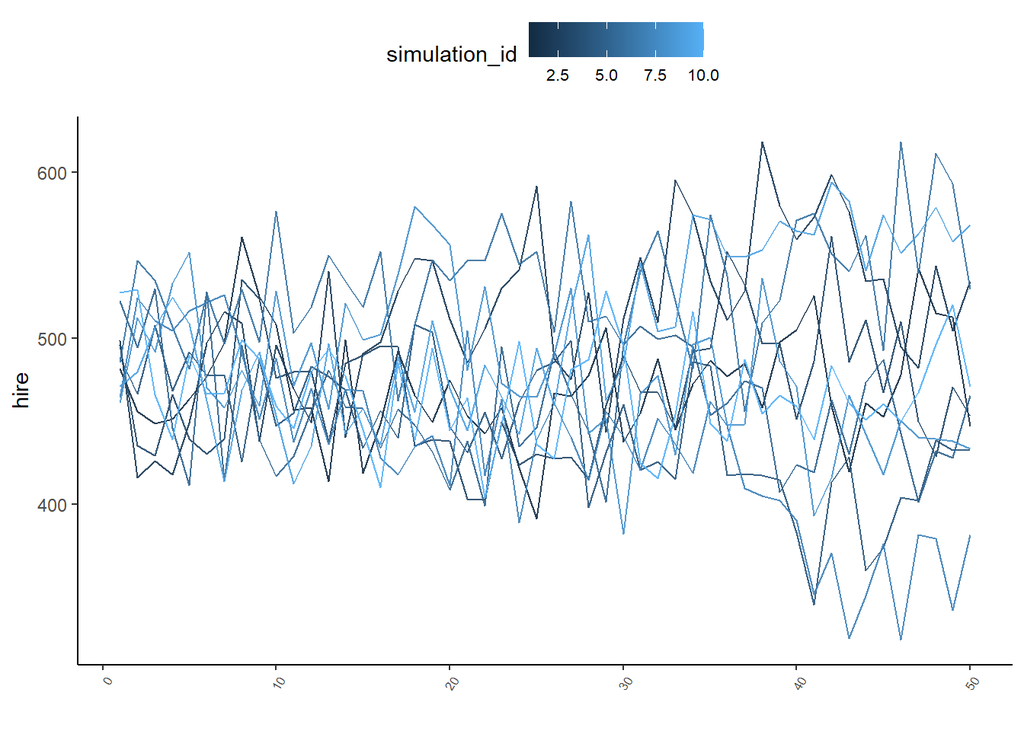

##### normalized_efficiency

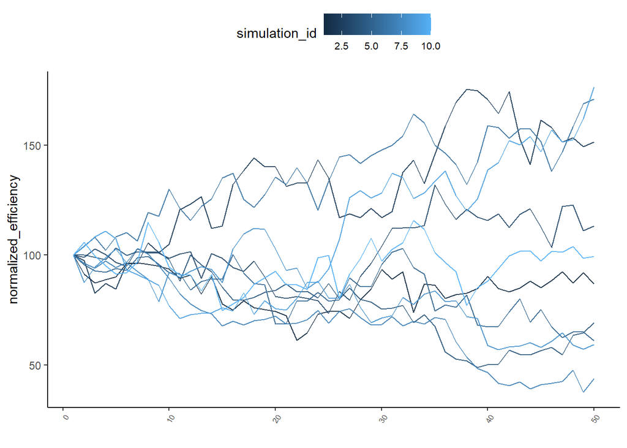

#### num_time_100_cobb_douglas_0.3_AR0_I1_va_dependency_0

##### unemployed

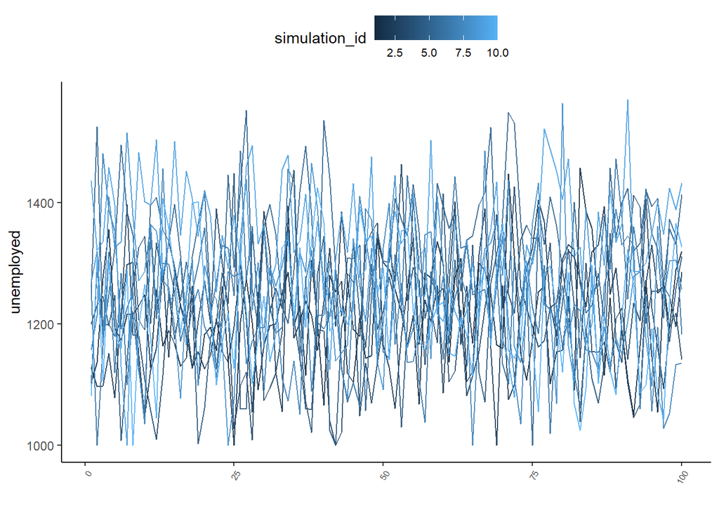

##### position_count

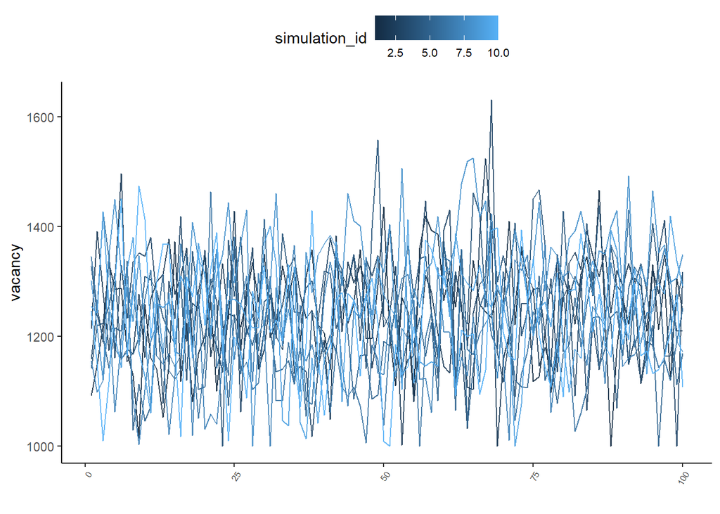

##### hire_count

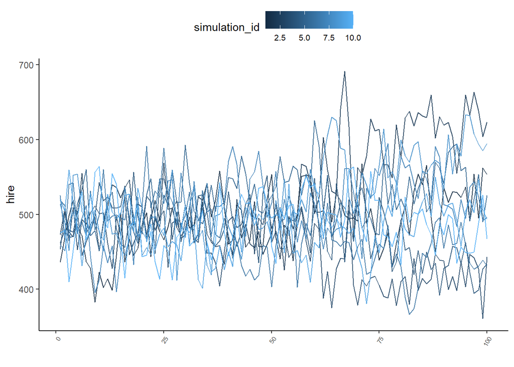

##### normalized_efficiency

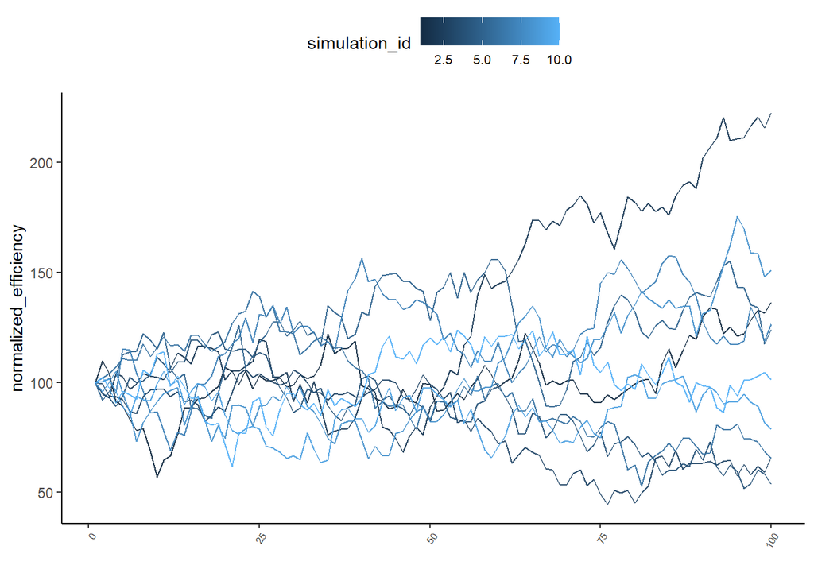

### perfect_substitute

#### num_time_50_perfect_substitute_0.3_AR0_I1_va_dependency_0

##### unemployed

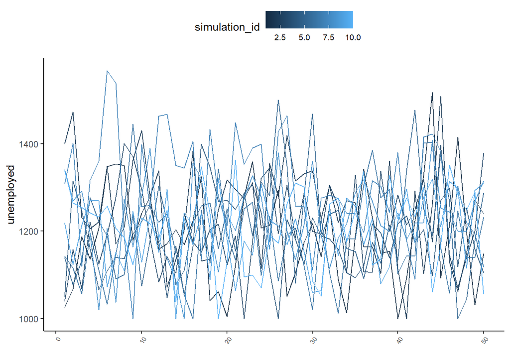

##### position_count

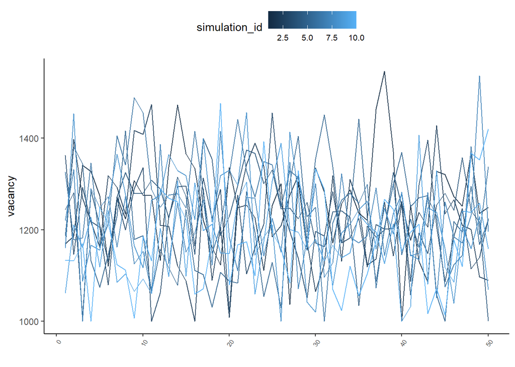

##### hire_count

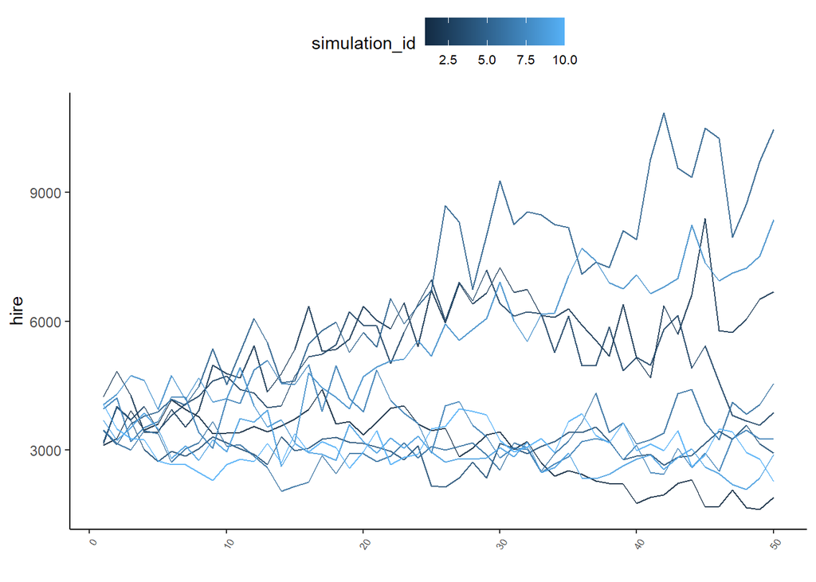

##### normalized_efficiency

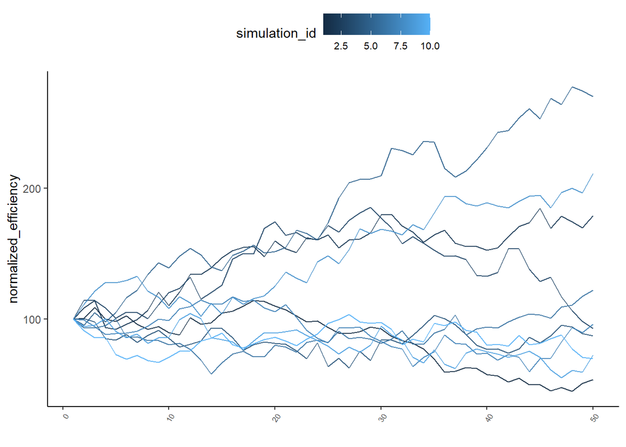

#### num_time_100_perfect_substitute_0.3_AR0_I1_va_dependency_0

##### unemployed

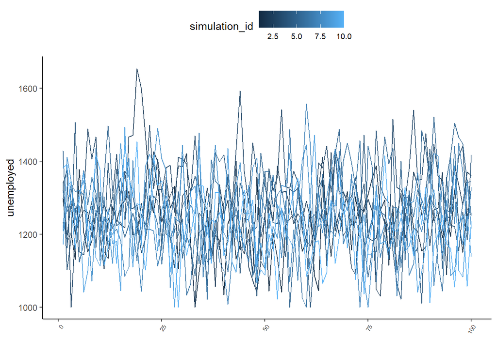

##### position_count

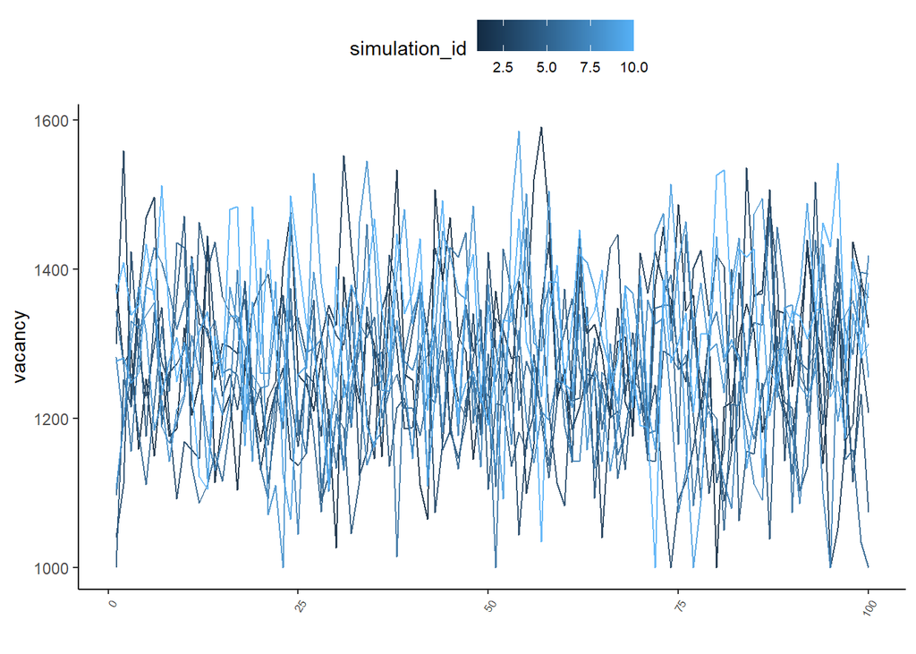

##### hire_count

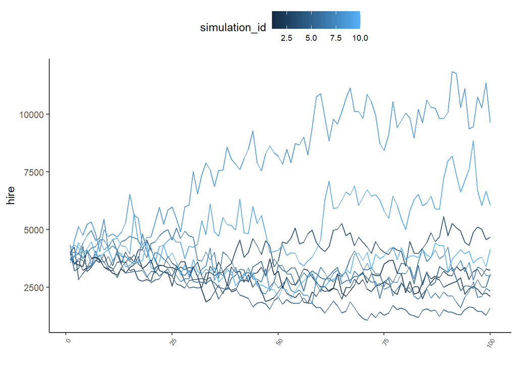

##### normalized_efficiency

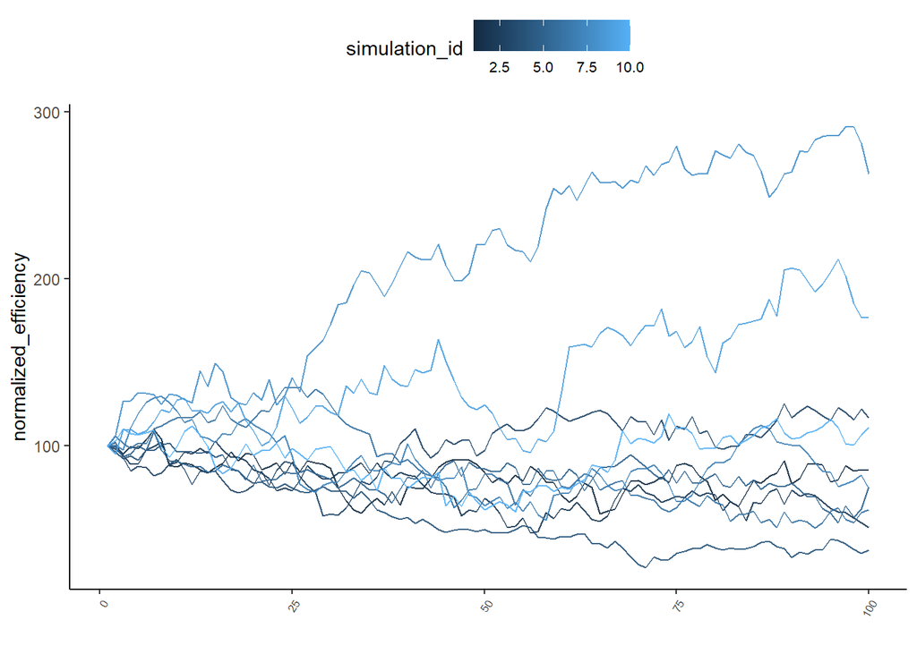